# Klasteryzacja przestrzenna danych punktowych

Julia Janczyk

2024-11-19

### Korzystamy z grupy metod opartej na analizie wzajemnego położenia i wzajemnych odległości punktów czyli gęstości przestrzennej punktów.

### Wczytujemy pliki z geometrią osiedli wraz z punktami

```r
library(dbscan) # klasteryzacja
library(sf) # do danych przestrzennych

setwd("C:/Users/jula7/Desktop/ja/Analiza danych prz/Projekt")
osiedla <- st_read("osiedla.shp")
punkty <- st_read("zestaw10_XYTableToPoint_Project.shp")
```

# Klasteryzacja

### Zbieramy koordynaty punktów na mapie

```r
koordynaty <- st_coordinates(punkty) # macierz
```

## Algorytm DBSCAN

### Density-based spatial clustering of applications with noise

### DBSCAN identyfikuje klastry jako regiony o wysokiej gęstości punktów, używając dwóch parametrów:

### eps – promień sąsiedztwa, w którym punkty są uważane za sąsiadów.

### minPts – minimalna liczba punktów w promieniu eps wymagana do utworzenia klastra.

### Punkty niespełniające tych kryteriów są klasyfikowane jako szum. Główną wadą jest to, że nie może dobrze klasteryzować zbiorów danych o dużych różnicach gęstości, ponieważ nie można wtedy odpowiednio dobrać kombinacji minPts - eps dla wszystkich klastrów.

```r
# esp - promień otoczenia w którym sprawdzamy ilość sąsiadów
# minPts - minimalna liczba punktów wymagana do utworzenia klastra
db1 <- dbscan(koordynaty, eps = 50, minPts = 5)  # 68 klastrów 1176 pkt szumu
db2 <- dbscan(koordynaty, eps = 500, minPts = 20) # 6  543
db3 <- dbscan(koordynaty, eps = 300, minPts = 10) # 16 539
db4 <- dbscan(koordynaty, eps = 400, minPts = 8)  # 22 289

db2
```

```
## DBSCAN clustering for 2000 objects.
## Parameters: eps = 500, minPts = 20
## Using euclidean distances and borderpoints = TRUE
## The clustering contains 6 cluster(s) and 543 noise points.
##
##    0    1    2    3    4    5    6
##  543 1211   96   52   39   34   25
##
## Available fields: cluster, eps, minPts, metric, borderPoints
```

### db1 - Maksymalny promień sąsiedztwa jest niski przez co wynik zawiera bardzo dużą ilość małych klastrów - 68. Zawiera również bardzo dużą ilość szumu - dużą ilość punktów niezliczających się do żadnego z klastrów.

### db2 - Wynik przez wysoki próg ilosci punktów tworzy jedynie 6 klastrów - z czego jeden zawiera ponad połowę rozpatrywanych punktów. Daje to bardzo ogólny wynik, który może zniekształcać rzeczywistą strukturę danych.

### db3 - Bardzo optymalny wynik - całkiem szczegółowy, wyraźnie wyodrębnione klastry. Uniwersalna ilość klastrów i ich umiarkowana wielkość, dodatkowo nieduża ilość punktów szumu - przejrzysta struktura danych.

### db4 - Może być to najbardziej opytmalny wynik - pozostawia bardzo mało punktów szumu, ma umiarkowaną ilość klastrów a struktura jest wyraźna, co pozwala łatwiej się do nich odnosić.

```r
# Tworzymy liste z wynikami DBSCAN
lista_klastrow <- list(
  wynik1 = db1$cluster,
  wynik2 = db2$cluster,
  wynik3 = db3$cluster,
  wynik4 = db4$cluster
)
```

## Algorytm HDBSCAN

### Hierarchical density-based spatial clustering of applications with noise

### Algortym ten jest rozwinięciem algorytmu DBSCAN. Identyfikuje tzw. rdzenie klastrów jako te punkty, w sąsiedztwie których zlokalizowana jest wystarczająca ilość punktów sąsiadujących dołączane są punkty pozostające w bliskiej odległości od któregokolwiek z punktów rdzenia.

### Punkty nienależące do żadengo z klastrów też są identyfikowane jako szum. Ten algortym ma lepsze działanie w przypadku danych o zmiennej gęstości.

```r
hdb1 <- hdbscan(koordynaty, minPts = 20) # 6  315
hdb2 <- hdbscan(koordynaty, minPts = 19) # 13 876
hdb3 <- hdbscan(koordynaty, minPts = 15) # 20 854
hdb4 <- hdbscan(koordynaty, minPts = 8)  # 12 226

# Wyniki HDBSCAN dodajemy do wczesniejszej listy
lista_klastrow <- append(lista_klastrow, list(
  wynik5 = hdb1$cluster,
  wynik6 = hdb2$cluster,
  wynik7 = hdb3$cluster,
  wynik8 = hdb4$cluster
))
```

### hdb1 - Wynik pierwszy wykrywa 6 dużych klastrów. Ustwione 20 punktów prowadzi do zbierania się większych skupisk punktów, pozostawia też niewielką ilość szumu. Pogrupowanie może być zbyt ogólne.

### hdb2 - Mimo niewielkiej zmiany w minPts znaleziono dwa razy więcej klastrów, które są mniejsze i pozostawiają znacznie więcej szumu. Dość szczegółowy wynik.

### hdb3 - Bardziej szczegółowy wynik, wieksza ilość klastrów - 20 (mimo prób nie został znaleziony parametr dający więcej klastrów). Struktura jest dość wyraźna, ale ilość punktów niezaliczających się do żadnego z klastrów jest całkiem duża, co może w pewnym stopniu zaburzyć jej obraz.

### hdb4 - Znacząco zredukowana ilość szumu - jedynie 226 punktów. Optymalna ilość klastrów dająca elastyczny wynik, który tworzy przejrzystą strukturę.

# Wizualizacja wyników

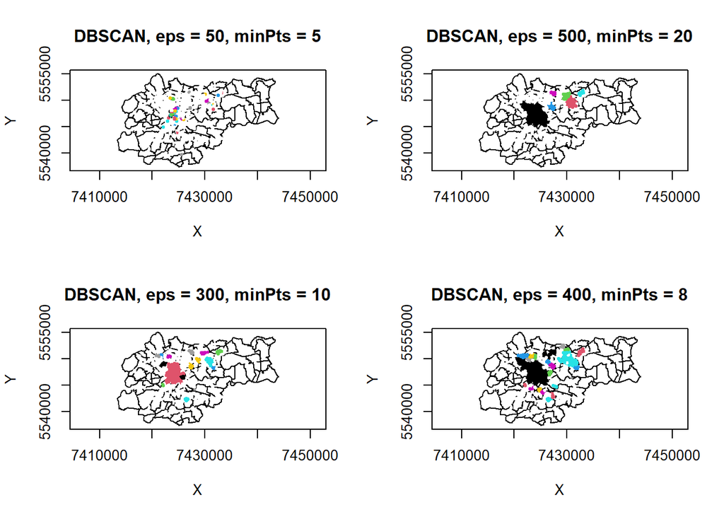

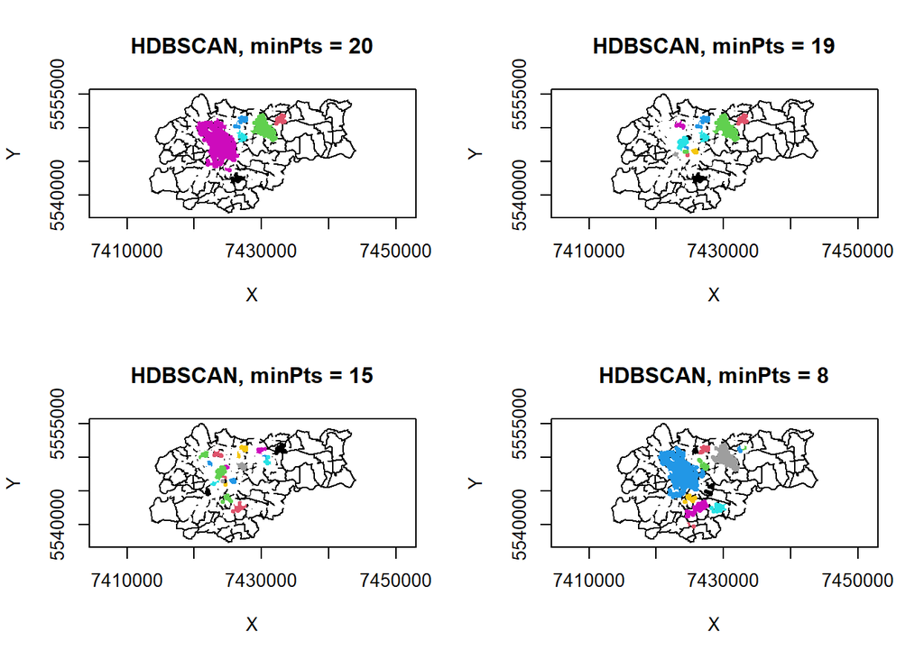

```r
lista_parametrow <- list(
  "DBSCAN, eps = 50, minPts = 5",
  "DBSCAN, eps = 500, minPts = 20",
  "DBSCAN, eps = 300, minPts = 10",
  "DBSCAN, eps = 400, minPts = 8",
  "HDBSCAN, minPts = 20",
  "HDBSCAN, minPts = 19",
  "HDBSCAN, minPts = 15",
  "HDBSCAN, minPts = 8"
)
par(mfrow = c(2, 2))

for (i in seq_along(lista_klastrow)) {
  plot(osiedla$geometry,
       main = lista_parametrow[i],
       axes = TRUE,
       xlab = "X",
       ylab = "Y")

  points(koordynaty,
         col = lista_klastrow[[i]],
         #col = ifelse(lista_klastrow[[i]] == 0, "gray", lista_klastrow[[i]]),
         # szary kolor dla punktów nienależących do żadnych klastrów - szum
         # gdyby tylko lista_klastrow[[i]] te punkty bedą białe - niewidoczne
         pch = 20,
         cex = 0.75)
}
```

# Wnioski

### Dobranie odpowiednich parametrów w DBSCAN jest trudne, ale wyniki są łatwiejsze do zrozumienia i interpretacji. W HDBSCAN nie mamy problemów z dobieraniem parametru eps co ułatwia pracę z nim. Jest on też lepszy w pracy z danymi o zmiennej gęstości.

### W wizualizacji wyników można zauważyć, że jeśli parametr eps jest zbyt mały, na wykresie mogą pojawiać się liczne małe grupy zamiast większych klastrów, natomiast zbyt duży prowadzi do stworzenia jednej dużej grupy.

### Jeden parametr w HDBSCAN sprawia, że jest mniejsza szansa na błędy spowodowane złym doborem parametrów. Przez to jednak mamy też mniejszy wpływ na wyniki - automatyczne działanie bez użycia eps.

### Algorytm HDBSCAN jest też bardziej wymagający obliczeniowo i wykonanie klasteryzacji zajmuje mu więcej czasu.